# Problem Statement (Brief)

Bike sharing systems are a means of renting bicycles where the process of obtaining membership, rental, and bike return is automated via a network of kiosk locations throughout a city. Using these systems, people are able to rent a bike from one location and return it to a different place on an as-needed basis. Currently, there are over 500 bike-sharing programs around the world. The data generated by these systems makes them attractive for researchers because the duration of travel, departure location, arrival location, and time elapsed is explicitly recorded. Bike sharing systems therefore function as a sensor network, which can be used for studying mobility in a city. In this project, you are asked to combine historical usage patterns with weather data in order to forecast hourly bike rental demand. You are provided with following files: 1.train.csv : Use this dataset to train the model. This file contains all the weather related features as well as the target variable “count”. Train dataset is comprised of first 18 months. 2.test.csv : Use the trained model to predict the count of total rentals for each hour during the next 6 months.

# Problem Statement (In Short)

Given data of bike sharing/rental app of past 18 months. ('datetime', 'season', 'holiday', 'workingday', 'weather', 'temp','atemp', 'humidity', 'windspeed', 'casual', 'registered', 'count') predict the count of total rentals for each hour during the next 6 months.

# Importing libraries

```python
import numpy as np
import pandas as pd
from datetime import datetime
from datetime import date
import calendar
import matplotlib.pyplot as plt
import seaborn as sn
%matplotlib inline
```

# Importing data

```python
train = pd.read_csv('a4train.csv')
test = pd.read_csv('a4test.csv')
```

# Dimensions of data

```python
train.shape
```

```
(12980, 12)
```

```python
test.shape
```

```
(4399, 11)
```

# Samples of data

```python
train.head()
```

|  | datetime | season | holiday | workingday | weather | temp | atemp | humidity | windspeed | casual | registered | count |
| --- | --- | --- | --- | --- | --- | --- | --- | --- | --- | --- | --- | --- |
| 0 | 2011-01-01 0:00:00 | 1 | 0 | 0 | 1 | 9.84 | 14.395 | 81.0 | 0.0 | 3 | 13 | 16 |
| 1 | 2011-01-01 1:00:00 | 1 | 0 | 0 | 1 | 9.02 | 13.635 | 80.0 | 0.0 | 8 | 32 | 40 |
| 2 | 2011-01-01 2:00:00 | 1 | 0 | 0 | 1 | 9.02 | 13.635 | 80.0 | 0.0 | 5 | 27 | 32 |
| 3 | 2011-01-01 3:00:00 | 1 | 0 | 0 | 1 | 9.84 | 14.395 | 75.0 | 0.0 | 3 | 10 | 13 |
| 4 | 2011-01-01 4:00:00 | 1 | 0 | 0 | 1 | 9.84 | 14.395 | 75.0 | 0.0 | 0 | 1 | 1 |

```python
test.head()
```

|  | datetime | season | holiday | workingday | weather | temp | atemp | humidity | windspeed | casual | registered |
| --- | --- | --- | --- | --- | --- | --- | --- | --- | --- | --- | --- |
| 0 | 2012-06-30 1:00:00 | 3 | 0 | 0 | 3 | 26.24 | 28.790 | 89.0 | 15.0013 | 3 | 55 |
| 1 | 2012-06-30 2:00:00 | 3 | 0 | 0 | 2 | 26.24 | 28.790 | 89.0 | 0.0000 | 7 | 54 |
| 2 | 2012-06-30 3:00:00 | 3 | 0 | 0 | 2 | 26.24 | 28.790 | 89.0 | 0.0000 | 3 | 20 |
| 3 | 2012-06-30 4:00:00 | 3 | 0 | 0 | 2 | 25.42 | 27.275 | 94.0 | 0.0000 | 3 | 15 |
| 4 | 2012-06-30 5:00:00 | 3 | 0 | 0 | 1 | 26.24 | 28.790 | 89.0 | 11.0014 | 3 | 7 |

# Overview of data

```python
train.columns
```

```
Index(['datetime', 'season', 'holiday', 'workingday', 'weather', 'temp',
       'atemp', 'humidity', 'windspeed', 'casual', 'registered', 'count'],
      dtype='object')
```

```python
test.columns
```

```
Index(['datetime', 'season', 'holiday', 'workingday', 'weather', 'temp',
       'atemp', 'humidity', 'windspeed', 'casual', 'registered'],
      dtype='object')
```

```python
train.dtypes
```

```
datetime       object
season          int64
holiday         int64
workingday      int64
weather         int64
temp          float64
atemp         float64
humidity      float64
windspeed     float64
casual          int64
registered      int64
count           int64
dtype: object
```

```python
test.dtypes
```

```
datetime       object
season          int64
holiday         int64
workingday      int64
weather         int64
temp          float64
atemp         float64
humidity      float64
windspeed     float64
casual          int64
registered      int64
dtype: object
```

# Univariate Analysis

```python
train["count"].describe()
```

```
count    12980.000000
mean       167.577812
std        160.758887
min          1.000000
25%         35.000000
50%        124.000000
75%        245.000000
max        957.000000
Name: count, dtype: float64
```

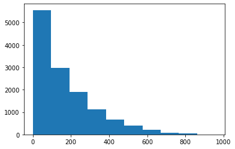

```python
plt.hist(train["count"])
```

"count" is right skewed. So, transform using Log()/square root/cube root.

# Variable Transformation

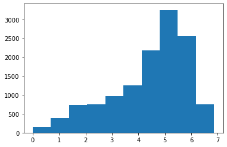

```python
plt.hist(np.log(train["count"]))
```

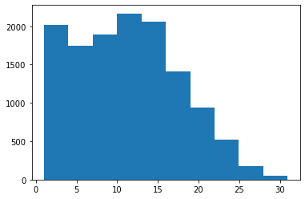

```python
plt.hist(np.sqrt(train["count"]))
```

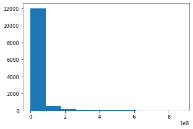

```python
plt.hist(np.power(train["count"],3))
```

From all Log() transformation is better

# Bivariate Analysis

```python
train.corr()
```

|  | season | holiday | workingday | weather | temp | atemp | humidity | windspeed | casual | registered | count |
| --- | --- | --- | --- | --- | --- | --- | --- | --- | --- | --- | --- |
| season | 1.000000 | -0.010959 | 0.014343 | -0.013005 | 0.394560 | 0.397765 | 0.181712 | -0.135762 | 0.104657 | 0.085699 | 0.100687 |
| holiday | -0.010959 | 1.000000 | -0.248558 | -0.018406 | -0.025104 | -0.032903 | -0.029520 | 0.021646 | 0.029135 | -0.046053 | -0.029340 |
| workingday | 0.014343 | -0.248558 | 1.000000 | 0.052788 | 0.060589 | 0.064840 | 0.028026 | 0.001986 | -0.307930 | 0.131819 | 0.018842 |
| weather | -0.013005 | -0.018406 | 0.052788 | 1.000000 | -0.093655 | -0.094877 | 0.432497 | 0.011120 | -0.161752 | -0.139034 | -0.161018 |
| temp | 0.394560 | -0.025104 | 0.060589 | -0.093655 | 1.000000 | 0.991839 | -0.048478 | -0.008669 | 0.459414 | 0.344451 | 0.415938 |
| atemp | 0.397765 | -0.032903 | 0.064840 | -0.094877 | 0.991839 | 1.000000 | -0.031606 | -0.049997 | 0.454015 | 0.342345 | 0.412644 |
| humidity | 0.181712 | -0.029520 | 0.028026 | 0.432497 | -0.048478 | -0.031606 | 1.000000 | -0.296975 | -0.320253 | -0.279501 | -0.322269 |
| windspeed | -0.135762 | 0.021646 | 0.001986 | 0.011120 | -0.008669 | -0.049997 | -0.296975 | 1.000000 | 0.079524 | 0.100579 | 0.105607 |
| casual | 0.104657 | 0.029135 | -0.307930 | -0.161752 | 0.459414 | 0.454015 | -0.320253 | 0.079524 | 1.000000 | 0.509175 | 0.707938 |
| registered | 0.085699 | -0.046053 | 0.131819 | -0.139034 | 0.344451 | 0.342345 | -0.279501 | 0.100579 | 0.509175 | 1.000000 | 0.968329 |
| count | 0.100687 | -0.029340 | 0.018842 | -0.161018 | 0.415938 | 0.412644 | -0.322269 | 0.105607 | 0.707938 | 0.968329 | 1.000000 |

Hence count is most dependent on registered var

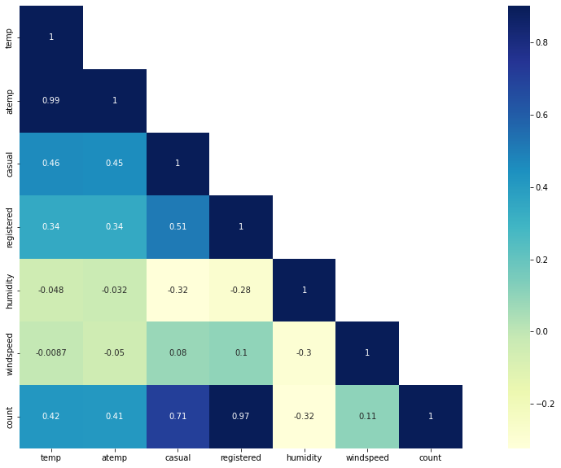

```python
corr = train[["temp","atemp","casual","registered","humidity","windspeed","count"]].corr()
mask = np.array(corr)
mask[np.tril_indices_from(mask)] = False
fig,ax= plt.subplots()
fig.set_size_inches(20,10)
sn.heatmap(corr, mask=mask,vmax=.9, square=True,annot=True, cmap="YlGnBu")
```

# Missing value Analysis

```python
train.isnull().sum()
```

```
datetime      0
season        0
holiday       0
workingday    0
weather       0
temp          0
atemp         0
humidity      0
windspeed     0
casual        0
registered    0
count         0
dtype: int64
```

No missing values

```python
test.isnull().sum()
```

```
datetime      0
season        0
holiday       0
workingday    0
weather       0
temp          0
atemp         0
humidity      0
windspeed     0
casual        0
registered    0
dtype: int64
```

No missing values

# Outlier analysis

[output not shown]

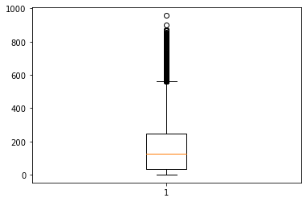

```python
plt.boxplot(train["count"])
```

# Model Building

```python
from sklearn.linear_model import LinearRegression
```

```python
LM = LinearRegression()
```

```python
# extracting date, hour and month from the datetime
train["date"] = train.datetime.apply(lambda x : x.split()[0])
train["hour"] = train.datetime.apply(lambda x : x.split()[1].split(":")[0])
train["month"] = train.date.apply(lambda dateString : datetime.strptime(dateString,"%Y-%m-%d").month)
```

```python
test["date"] = test.datetime.apply(lambda x : x.split()[0])
test["hour"] = test.datetime.apply(lambda x : x.split()[1].split(":")[0])
test["month"] = test.date.apply(lambda dateString : datetime.strptime(dateString,"%Y-%m-%d").month)
```

```python
training = train[train['datetime']<='2012-03-30 0:00:00']
validation = train[train['datetime']>'2012-03-30 0:00:00']
```

```python
# filter out unwanted vars
train = train.drop(['datetime','date', 'atemp'],axis=1)
test = test.drop(['datetime','date', 'atemp'], axis=1)
training = training.drop(['datetime','date', 'atemp'],axis=1)
validation = validation.drop(['datetime','date', 'atemp'],axis=1)
```

```python
X_train = train.drop('count', 1)
X_train = X_train[:10774]
y_train = np.log(training['count'])
X_val = validation.drop('count', 1)
y_val = np.log(validation['count'])
```

```
C:\Users\aatif mohammad\AppData\Local\Temp/ipykernel_16776/1787626603.py:1: FutureWarning: In a future version of pandas all arguments of DataFrame.drop except for the argument 'labels' will be keyword-only
  X_train = train.drop('count', 1)
C:\Users\aatif mohammad\AppData\Local\Temp/ipykernel_16776/1787626603.py:4: FutureWarning: In a future version of pandas all arguments of DataFrame.drop except for the argument 'labels' will be keyword-only
  X_val = validation.drop('count', 1)
```

```python
# checking the shape of X_train, y_train, X_val and y_val
X_train.shape, y_train.shape, X_val.shape, y_val.shape
```

```
((10774, 11), (10774,), (2206, 11), (2206,))
```

```python
# fitting the model on X_train and y_train
LM.fit(X_train,y_train)
```

```
LinearRegression()
```

```python
# making prediction on validation set
prediction = LM.predict(X_val)
```

# Evalutaion

Metrics = RMSLE (Root Mean Square Log Evaluation)

```python
# defining a function which will return the rmsle score
def rmsle(y, y_):
    y = np.exp(y),   # taking the exponential as we took the log of target variable
    y_ = np.exp(y_)
    log1 = np.nan_to_num(np.array([np.log(v + 1) for v in y]))
    log2 = np.nan_to_num(np.array([np.log(v + 1) for v in y_]))
    calc = (log1 - log2) ** 2
    return np.sqrt(np.mean(calc))
```

```python
rmsle(y_val,prediction)
```

```
0.8875379204281779
```

```python
test_prediction = LM.predict(test)
```

# Decision Tree

```python
from sklearn.tree import DecisionTreeRegressor
```

```python
# defining a decision tree model with a depth of 5. You can further tune the hyperparameters to improve the score
dt_reg = DecisionTreeRegressor(max_depth=5)
```

```python
dt_reg.fit(X_train, y_train)
```

```
DecisionTreeRegressor(max_depth=5)
```

```python
predict = dt_reg.predict(X_val)
```

```python
# calculating rmsle of the predicted values
rmsle(y_val, predict)
```

```
0.1710226739944692
```

# Prediction

```python
test_prediction = dt_reg.predict(test)
```

```python
final_prediction = np.exp(test_prediction)
```

Fetching Results

```python
predictions = pd.DataFrame()
predictions['count'] = final_prediction
predictions.to_csv('predictions.csv', header=True, index=False)
```

```python
a=pd.read_csv("predictions.csv")
a.head(25)
```

|  | count |
| --- | --- |
| 0 | 67.337495 |
| 1 | 67.337495 |
| 2 | 22.218489 |
| 3 | 14.518412 |
| 4 | 8.652763 |
| 5 | 46.034568 |
| 6 | 94.214889 |
| 7 | 206.333712 |
| 8 | 289.819923 |
| 9 | 386.357422 |
| 10 | 386.357422 |
| 11 | 386.357422 |
| 12 | 386.357422 |
| 13 | 386.357422 |
| 14 | 386.357422 |
| 15 | 386.357422 |
| 16 | 386.357422 |
| 17 | 386.357422 |
| 18 | 386.357422 |
| 19 | 248.166665 |
| 20 | 206.333712 |
| 21 | 166.948439 |
| 22 | 140.869164 |
| 23 | 120.412029 |
| 24 | 94.214889 |